# R Notebook

# t-Test für eine Stichprobe erklärt den Vergleich eines Erwartungswertes:

### Einführung

Der t-Test für eine Stichprobe prüft anhand des Mittelwertes einer Stichprobe, ob der Mittelwert einer Grundgesamtheit gleich einem vorgegebenen Wert ist (bzw. kleiner oder größer).

Die Fragestellung des t-Tests für eine Stichprobe wird oft so verkürzt: “Unterscheiden sich die Mittelwerte zwischen Grundgesamtheit und Stichprobe?”

### Beispiele

Gibt es einen Unterschied im Mittelwert zwischen dem IQ aus der Stichprobe und dem durchschnittlichen IQ aus Deutschland? Gibt es einen Unterschied zwischen dem Mittelwert des Marktingbugets der Firma “Klein” und dem Branchendurchschnitt?

✓ Die Variable ist min. intervallskaliert ✓ Die Variable ist in die Grundgesamtheit normalverteilt

# Beispiel einer Studie:

Als Kontrollvariable wird der IQ erhoben. Es hat sich nämlich in anderen Testverfahren herausgestellt, dass der IQ ein Störfaktor darstellt. Daher soll nun unterschucht werden, ob der IQ aus der Stichprobe sich vom Durchschnitts-IQ in Deutschland unterscheidet.

## Datensatz einlesen

```r
IQ <- read.csv("uebung5.csv")
```

## Überblick über die Daten

```r
head(IQ)
```

|  | X | IQbio | IQfoster | class |
| --- | --- | --- | --- | --- |
| 1 | 1 | 82 | 82 | high |
| 2 | 2 | 80 | 90 | high |
| 3 | 3 | 88 | 91 | high |
| 4 | 4 | 108 | 115 | high |
| 5 | 5 | 116 | 115 | high |
| 6 | 6 | 117 | 129 | high |

```r
str(IQ)
```

```
'data.frame':   27 obs. of  4 variables:
 $ X       : int  1 2 3 4 5 6 7 8 9 10 ...
 $ IQbio   : int  82 80 88 108 116 117 132 71 75 93 ...
 $ IQfoster: int  82 90 91 115 115 129 131 78 79 82 ...
 $ class   : chr  "high" "high" "high" "high" ...
```

# 1) Hypothese

H1: Es gibt einen Unterschied zwischen dem Durchschnitts-IQ in Deutschland und dem IQ aus der Stichprobe.

H0: Es gibt keinen Unterschied zwischen dem Durchschnitts-IQ in Deutschland und dem IQ aus der Stichprobe.

# 2) Voraussetzungen für den t-Tests für eine Stichprobe

✓ Die Variable ist min. intervallskaliert -> IQ_bio ist metrisch ✓ Die Variable ist in die Grundgesamtheite normalverteilt -> siehe Histogramm

### Prüfung der Normalverteilung mittels Histogramm

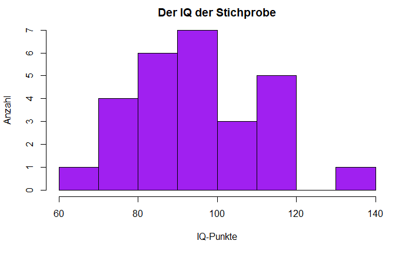

```r
hist(IQ$IQbio, main = "Der IQ der Stichprobe", xlab ="IQ-Punkte", ylab = "Anzahl", col = "purple")
```

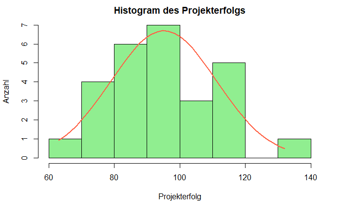

```r
x <- IQ$IQbio
h<-hist(x, breaks=5, col="lightgreen", xlab="Projekterfolg",
main="Histogram des Projekterfolgs",
ylab= "Anzahl")
xfit<-seq(min(x),max(x),length=40)
yfit<-dnorm(xfit,mean=mean(x),sd=sd(x))
yfit <- yfit*diff(h$mids[1:2])*length(x)
lines(xfit, yfit, col="tomato", lwd=2)
```

### Prüfung der Normalverteilung mittels QQPlot

```
[1]  7 14
```

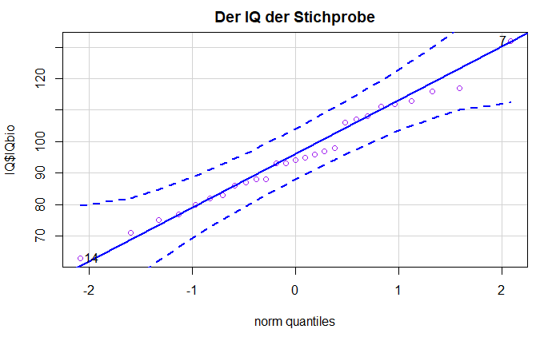

```r
library(car)
qqPlot(IQ$IQbio, main = "Der IQ der Stichprobe", col = "purple")
```

Es liegt eine Normalverteilung vor.

# 3) Ergebnis der Auswertung

Der DurchschnittsIQ in Deutschland liegt bei 100 IQ-Punkten.

```r
t.test(IQ$IQbio, mu=100)
```

```
    One Sample t-test

data:  IQ$IQbio
t = -1.5796, df = 26, p-value = 0.1263
alternative hypothesis: true mean is not equal to 100
95 percent confidence interval:
  88.74916 101.47307
sample estimates:
mean of x
 95.11111
```

## z-Transformation

```r
psych::describe(IQ$IQbio)
```

|  | vars | n | mean | sd | median | trimmed | mad | min | max | range | skew | kurtosis | se |
| --- | --- | --- | --- | --- | --- | --- | --- | --- | --- | --- | --- | --- | --- |
| X1 | 1 | 27 | 95.11 | 16.08 | 94 | 95 | 17.79 | 63 | 132 | 69 | 0.17 | -0.58 | 3.1 |

```r
IQ_Bio_Z <- scale(IQ$IQbio)
```

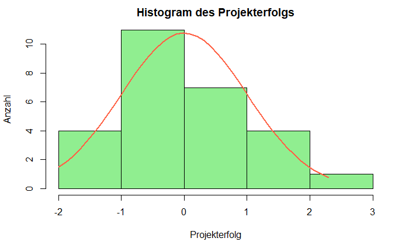

```r
x <- IQ_Bio_Z
h<-hist(x, breaks=5, col="lightgreen", xlab="Projekterfolg",
main="Histogram des Projekterfolgs",
ylab= "Anzahl")
xfit<-seq(min(x),max(x),length=40)
yfit<-dnorm(xfit,mean=mean(x),sd=sd(x))
yfit <- yfit*diff(h$mids[1:2])*length(x)
lines(xfit, yfit, col="tomato", lwd=2)
```

### Hinzufügen der Z-Werte zum Datensatz

```r
IQ<- cbind(IQ, "IQBio_Z" = IQ_Bio_Z)
View(IQ)
IQ$IQBio_Z <- NULL # Die Spalte löschen, falls zu viele Z-Werte hinzugefügt wurden
```

### Alternative

```r
IQ["IQBio_z"] <- IQ_Bio_Z
View(IQ)
```

## Auswertung des z-Testes für eine Stichprobe

$$z = \frac {(x-µ)}{σ} = \frac {(100 -95.11)}{16.08} = 0.3041$$

```r
sprintf("Der Z-Wert für den DurchschnittsIQ aus Deutschland ist: %f:",((100 -95.11)/16.08))
```

```
[1] "Der Z-Wert für den DurchschnittsIQ aus Deutschland ist: 0.304104:"
```

```r
t.test(IQ$IQBio_z, mu = 0.304)
```

```
    One Sample t-test

data:  IQ$IQBio_z
t = -1.5796, df = 26, p-value = 0.1263
alternative hypothesis: true mean is not equal to 0.304
95 percent confidence interval:
 -0.3955868  0.3955868
sample estimates:
   mean of x
-1.96356e-16
```